# hw5 markdown

Setup includes clearing the environment, setting the seed to 1, and saving data set to variable ‘dat’

```r
rm(list = ls())
set.seed(1)
dat <- read.table('uscrime.txt', stringsAsFactors=FALSE, header=TRUE)
```

Head of dat

```r
head(dat)
```

```
##      M So   Ed  Po1  Po2    LF   M.F Pop   NW    U1  U2 Wealth Ineq
## 1 15.1  1  9.1  5.8  5.6 0.510  95.0  33 30.1 0.108 4.1   3940 26.1
## 2 14.3  0 11.3 10.3  9.5 0.583 101.2  13 10.2 0.096 3.6   5570 19.4
## 3 14.2  1  8.9  4.5  4.4 0.533  96.9  18 21.9 0.094 3.3   3180 25.0
## 4 13.6  0 12.1 14.9 14.1 0.577  99.4 157  8.0 0.102 3.9   6730 16.7
## 5 14.1  0 12.1 10.9 10.1 0.591  98.5  18  3.0 0.091 2.0   5780 17.4
## 6 12.1  0 11.0 11.8 11.5 0.547  96.4  25  4.4 0.084 2.9   6890 12.6
##       Prob    Time Crime
## 1 0.084602 26.2011   791
## 2 0.029599 25.2999  1635
## 3 0.083401 24.3006   578
## 4 0.015801 29.9012  1969
## 5 0.041399 21.2998  1234
## 6 0.034201 20.9995   682
```

We use the entire dataset to build a regression model which is then used for prediction We’re not choosing between models (so validation isn’t needed) and we’re not bothering to estimate model quality (so test data isn’t needed)

summary of model

```r
model <- lm( Crime ~ ., data = dat)
summary(model)
```

```
##
## Call:
## lm(formula = Crime ~ ., data = dat)
##
## Residuals:
##     Min      1Q  Median      3Q     Max
## -395.74  -98.09   -6.69  112.99  512.67
##
## Coefficients:
##               Estimate Std. Error t value Pr(>|t|)
## (Intercept) -5.984e+03  1.628e+03  -3.675 0.000893 ***
## M            8.783e+01  4.171e+01   2.106 0.043443 *
## So          -3.803e+00  1.488e+02  -0.026 0.979765
## Ed           1.883e+02  6.209e+01   3.033 0.004861 **
## Po1          1.928e+02  1.061e+02   1.817 0.078892 .
## Po2         -1.094e+02  1.175e+02  -0.931 0.358830
## LF          -6.638e+02  1.470e+03  -0.452 0.654654
## M.F          1.741e+01  2.035e+01   0.855 0.398995
## Pop         -7.330e-01  1.290e+00  -0.568 0.573845
## NW           4.204e+00  6.481e+00   0.649 0.521279
## U1          -5.827e+03  4.210e+03  -1.384 0.176238
## U2           1.678e+02  8.234e+01   2.038 0.050161 .
## Wealth       9.617e-02  1.037e-01   0.928 0.360754
## Ineq         7.067e+01  2.272e+01   3.111 0.003983 **
## Prob        -4.855e+03  2.272e+03  -2.137 0.040627 *
## Time        -3.479e+00  7.165e+00  -0.486 0.630708
## ---
## Signif. codes:  0 '***' 0.001 '**' 0.01 '*' 0.05 '.' 0.1 ' ' 1
##
## Residual standard error: 209.1 on 31 degrees of freedom
## Multiple R-squared:  0.8031, Adjusted R-squared:  0.7078
## F-statistic: 8.429 on 15 and 31 DF,  p-value: 3.539e-07
```

Test datapoint

```r
test <-data.frame(M = 14.0,So = 0, Ed = 10.0, Po1 = 12.0, Po2 = 15.5,LF = 0.640, M.F = 94.0, Pop = 150, NW = 1.1, U1 = 0.120, U2 = 3.6, Wealth = 3200, Ineq = 20.1, Prob = 0.040,Time = 39.0)

pred_model <- predict(model, test)
pred_model
```

```
##        1
## 155.4349
```

Let’s go back and just use the singificant factors to get an estimate. We’ll try using all of the factors with p<=0.1. (In Module 11, we’ll see better ways of going about this.)

```r
model2 <- lm( Crime ~  M + Ed + Po1 + U2 + Ineq + Prob, data = dat)
summary(model2)
```

```
##
## Call:
## lm(formula = Crime ~ M + Ed + Po1 + U2 + Ineq + Prob, data = dat)
##
## Residuals:
##     Min      1Q  Median      3Q     Max
## -470.68  -78.41  -19.68  133.12  556.23
##
## Coefficients:
##             Estimate Std. Error t value Pr(>|t|)
## (Intercept) -5040.50     899.84  -5.602 1.72e-06 ***
## M             105.02      33.30   3.154  0.00305 **
## Ed            196.47      44.75   4.390 8.07e-05 ***
## Po1           115.02      13.75   8.363 2.56e-10 ***
## U2             89.37      40.91   2.185  0.03483 *
## Ineq           67.65      13.94   4.855 1.88e-05 ***
## Prob        -3801.84    1528.10  -2.488  0.01711 *
## ---
## Signif. codes:  0 '***' 0.001 '**' 0.01 '*' 0.05 '.' 0.1 ' ' 1
##
## Residual standard error: 200.7 on 40 degrees of freedom
## Multiple R-squared:  0.7659, Adjusted R-squared:  0.7307
## F-statistic: 21.81 on 6 and 40 DF,  p-value: 3.418e-11
```

Predict on our test observation

```r
pred_model2 <- predict(model2, test)
pred_model2
```

```
##        1
## 1304.245
```

Model quality

```r
# Install the DAAG package, which has cross-validation functions

#install.packages("DAAG")
library(DAAG)
c <- cv.lm(dat,model2,m=5) # note that here, "m" is used for the number of folds, rather than the usual "k"
```

```
## Analysis of Variance Table
##
## Response: Crime
##           Df  Sum Sq Mean Sq F value  Pr(>F)
## M          1   55084   55084    1.37 0.24914
## Ed         1  725967  725967   18.02 0.00013 ***
## Po1        1 3173852 3173852   78.80 5.3e-11 ***
## U2         1  217386  217386    5.40 0.02534 *
## Ineq       1  848273  848273   21.06 4.3e-05 ***
## Prob       1  249308  249308    6.19 0.01711 *
## Residuals 40 1611057   40276
## ---
## Signif. codes:  0 '***' 0.001 '**' 0.01 '*' 0.05 '.' 0.1 ' ' 1
```

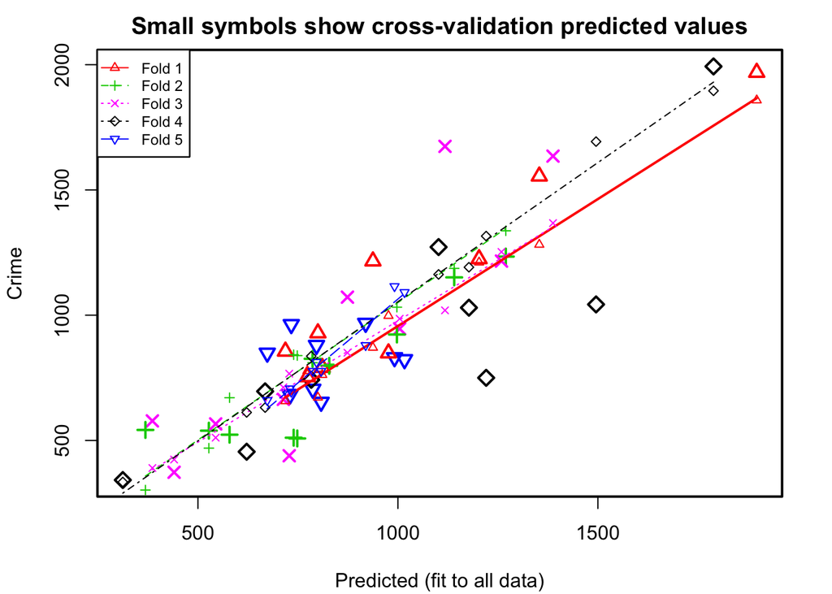

```
##
## fold 1
## Observations in test set: 9
##                 1    4    8   9  18     20   23    32   47
## Predicted   810.8 1897 1354 719 800 1203.0  938 773.7  976
## cvpred      762.1 1858 1282 657 672 1210.8  871 777.6  998
## Crime       791.0 1969 1555 856 929 1225.0 1216 754.0  849
## CV residual  28.9  111  273 199 257   14.2  345 -23.6 -149
##
## Sum of squares = 335463    Mean square = 37274    n = 9
##
## fold 2
## Observations in test set: 10
##                5   13     15    17   25   34    39   40  42   46
## Predicted   1270  739 828.34 527.4  579  998 786.7 1141 369  748
## cvpred      1337  842 804.73 469.3  671 1032 810.3 1187 302  839
## Crime       1234  511 798.00 539.0  523  923 826.0 1151 542  508
## CV residual -103 -331  -6.73  69.7 -148 -109  15.7  -36 240 -331
##
## Sum of squares = 327423    Mean square = 32742    n = 10
##
## fold 3
## Observations in test set: 10
##                2   3   11    14     16   22     28    31   33    38
## Predicted   1388 386 1118 713.6 1004.4  728 1259.0 440.4  874 544.4
## cvpred      1368 390 1019 711.8  985.8  767 1252.6 423.8  850 511.2
## Crime       1635 578 1674 664.0  946.0  439 1216.0 373.0 1072 566.0
## CV residual  267 188  655 -47.8  -39.8 -328  -36.6 -50.8  222  54.8
##
## Sum of squares = 702726    Mean square = 70273    n = 10
##
## fold 4
## Observations in test set: 9
##               19    21     26     27   29    30   36   44   45
## Predicted   1221 783.3 1789.1 312.20 1495 668.0 1102 1178  622
## cvpred      1316 836.4 1895.7 334.15 1693 631.2 1163 1191  612
## Crime        750 742.0 1993.0 342.00 1043 696.0 1272 1030  455
## CV residual -566 -94.4   97.3   7.85 -650  64.8  109 -161 -157
##
## Sum of squares = 827924    Mean square = 91992    n = 9
##
## fold 5
## Observations in test set: 9
##               6   7    10  12    24   35   37    41   43
## Predicted   730 733 787.3 673 919.4  808  992 796.4 1017
## cvpred      707 694 776.8 660 879.7  777 1115 812.6 1091
## Crime       682 963 705.0 849 968.0  653  831 880.0  823
## CV residual -25 269 -71.8 189  88.3 -124 -284  67.4 -268
##
## Sum of squares = 294201    Mean square = 32689    n = 9
##
## Overall (Sum over all 9 folds)
##    ms
## 52931
```

```r
c
```

[output not shown]

[output cut: 81 more lines]

The overall mean squared prediction error in cross-validation is shown as “ms”. NOTE that there seems to be a typo in cv.lm – when it says “sum over all n folds”, n is actually the number of data points in the last fold, not the number of folds.

We can calculate the R-squared values directly. R-squared = 1 - SSEresiduals/SSEtotal total sum of squared differences between data and its mean

```r
SStot <- sum((dat$Crime - mean(dat$Crime))^2)
```

```r
# for model, model2, and cross-validation, calculated SEres

SSres_model <- sum(model$residuals^2)

SSres_model2 <- sum(model2$residuals^2)

SSres_c <- attr(c,"ms")*nrow(dat) # mean squared error, times number of data points, gives sum of squared errors

# Calculate R-squareds for model, model2, cross-validation

1 - SSres_model/SStot # initial model with insignificant factors
```

```
## [1] 0.803
```

```r
## 0.803

1 - SSres_model2/SStot # model2 without insignificant factors
```

```
## [1] 0.766
```

```r
## 0.766

1 - SSres_c/SStot # cross-validated
```

```
## [1] 0.638
```

```r
## 0.638

# So, this shows that including the insignificant factors overfits compared to removing them,
# and even the fitted model is probably overfitted.
# That's not so surprising, since we started with just 47 data points and we have 15 factors to predict from.
# The ratio of data points to factors is about 3:1,
# and it's usually good to have 10:1 or more.
#
# We'll see in Module 11 ways we can try to get around this problem.

# We can also try cross-validation on the first, 15-factor model

cfirst <- cv.lm(dat,model,m=5)
```

```
## Analysis of Variance Table
##
## Response: Crime
##           Df  Sum Sq Mean Sq F value  Pr(>F)
## M          1   55084   55084    1.26  0.2702
## So         1   15370   15370    0.35  0.5575
## Ed         1  905668  905668   20.72 7.7e-05 ***
## Po1        1 3076033 3076033   70.38 1.8e-09 ***
## Po2        1  153024  153024    3.50  0.0708 .
## LF         1   61134   61134    1.40  0.2459
## M.F        1  111000  111000    2.54  0.1212
## Pop        1   42649   42649    0.98  0.3309
## NW         1   14197   14197    0.32  0.5728
## U1         1    7065    7065    0.16  0.6904
## U2         1  269663  269663    6.17  0.0186 *
## Wealth     1   34748   34748    0.79  0.3795
## Ineq       1  547423  547423   12.52  0.0013 **
## Prob       1  222620  222620    5.09  0.0312 *
## Time       1   10304   10304    0.24  0.6307
## Residuals 31 1354946   43708
## ---
## Signif. codes:  0 '***' 0.001 '**' 0.01 '*' 0.05 '.' 0.1 ' ' 1
```

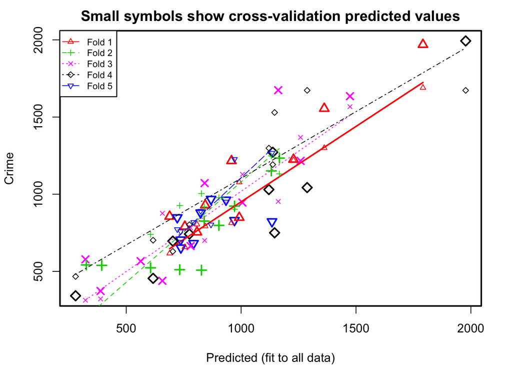

```
##
## fold 1
## Observations in test set: 9
##               1    4    8   9  18      20   23    32   47
## Predicted   755 1791 1362 689 844 1227.84  958 807.8  992
## cvpred      658 1690 1300 617 792 1220.22  814 804.9 1077
## Crime       791 1969 1555 856 929 1225.00 1216 754.0  849
## CV residual 133  279  255 239 137    4.78  402 -50.9 -228
##
## Sum of squares = 453204    Mean square = 50356    n = 9
##
## fold 2
## Observations in test set: 10
##                5   13   15  17   25    34    39     40    42   46
## Predicted   1167  733  903 393  606 971.5 839.3 1131.5 326.3  827
## cvpred      1132  926  977 152  740 902.7 918.1 1248.5  62.3 1004
## Crime       1234  511  798 539  523 923.0 826.0 1151.0 542.0  508
## CV residual  102 -415 -179 387 -217  20.3 -92.1  -97.5 479.7 -496
##
## Sum of squares = 906384    Mean square = 90638    n = 10
##
## fold 3
## Observations in test set: 10
##                  2   3   11   14   16   22   28    31   33      38
## Predicted   1473.7 322 1161  780 1006  657 1258 388.0  841 562.693
## cvpred      1566.9 313  953  782 1129  876 1368 321.7  700 566.231
## Crime       1635.0 578 1674  664  946  439 1216 373.0 1072 566.000
## CV residual   68.1 265  721 -118 -183 -437 -152  51.3  372  -0.231
##
## Sum of squares = 997216    Mean square = 99722    n = 10
##
## fold 4
## Observations in test set: 9
##               19    21   26   27   29    30     36   44   45
## Predicted   1146 774.9 1977  279 1287 702.7 1137.6 1121  617
## cvpred      1529 802.3 1673  467 1673 629.6 1191.9 1298  702
## Crime        750 742.0 1993  342 1043 696.0 1272.0 1030  455
## CV residual -779 -60.3  320 -125 -630  66.4   80.1 -268 -247
##
## Sum of squares = 1269688    Mean square = 141076    n = 9
##
## fold 5
## Observations in test set: 9
##                6     7    10    12  24    35   37  41   43
## Predicted    793 934.2 736.5 722.0 869 737.8  971 824 1134
## cvpred       819 950.9 758.1 772.5 802 690.5 1227 891 1267
## Crime        682 963.0 705.0 849.0 968 653.0  831 880  823
## CV residual -137  12.1 -53.1  76.5 166 -37.5 -396 -11 -444
##
## Sum of squares = 410109    Mean square = 45568    n = 9
##
## Overall (Sum over all 9 folds)
##    ms
## 85885
```

```r
SSres_cfirst <- attr(cfirst,"ms")*nrow(dat) # mean squared error, times number of data points, gives sum of squared errors

1 - SSres_cfirst/SStot # cross-validated
```

```
## [1] 0.413
```

```r
## 0.413

# That's a huge difference from the 0.803 reported by lm() on the training data, which demonstrates the need to validate!
```